# Lab 1: Media campionaria

Analisi dei Dati 2023-24

Cristiano Varin

In questo documento utilizziamo **R** per illustrare alcune proprietà della media campionaria. Per prima cosa creiamo una fittizia popolazione simulando da una distribuzione nota. Per esempio, simuliamo una popolazione formata da 5000 tempi di elaborazione CPU di un processo da una distribuzione esponenziale di media 40 secondi. La distribuzione esponenziale è una distribuzione continua che assume valori non negativi con funzione di densità
$$f(x; \lambda)=\begin{cases}
\lambda e^{-\lambda x}, & \text{se} \; x \geq 0, \\
0, & \text{altrimenti.}
\end{cases}$$
Il valore atteso della distribuzione esponenziale è pari a $1/\lambda$ (verificatelo). Possiamo disegnare la funzione di densità $f(x; 1/40)$ con la funzione `dexp` in cui il parametro $\lambda$ è chiamato `rate`[^1]:

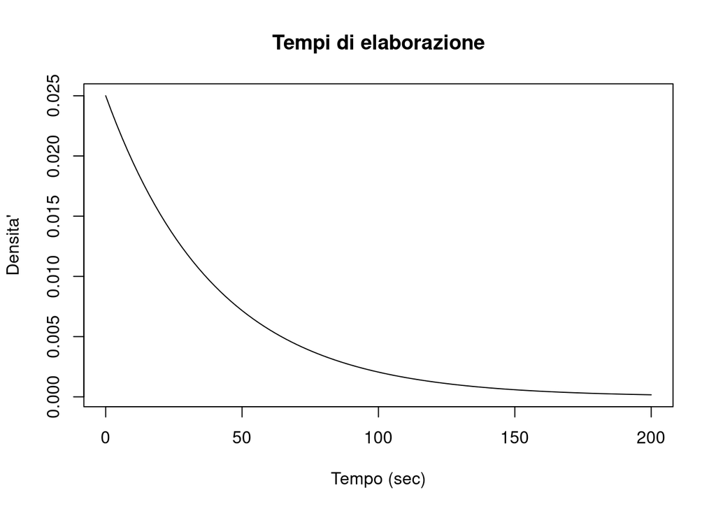

```r
curve(dexp(x, rate = 1 / 40), main = "Tempi di elaborazione", xlim = c(0, 200), xlab = "Tempo (sec)", ylab = "Densita'")
```

Simuliamo i 5000 tempi di elaborazione dalla distribuzione esponenziale di media 40 secondi usando la funzione `rexp`:

```r
## fissiamo il seme del generatore pseudo-casuale per garantire la reproducibilita' delle analisi
set.seed(123)
## simulazioni
popolazione <- rexp(n = 5000, rate = 1 / 40)
```

La media della “popolazione dei tempi di elaborazione” che abbiamo simulato è

```r
media.pop <- mean(popolazione)
media.pop
```

```
## [1] 40.34682
```

Possiamo estrarre un campione casuale semplice di 50 tempi dalla popolazione usando la funzione `sample`:

```r
campione <- sample(popolazione, size = 50)
## prime osservazioni del campione
head(campione)
```

```
## [1]  33.85771  11.11401  24.17462  46.10723 162.89303  44.29754
```

La media campionaria è pari a

```r
mean(campione)
```

```
## [1] 41.62338
```

In questo caso sovrastimiamo la media di popolazione. Se ripetiamo l’esperimento estraendo un altro campione casuale semplice di dimensione 50 otteniamo invece una sottostima:

```r
mean(sample(popolazione, size = 50))
```

```
## [1] 36.79305
```

Proviamo ora a ripetere l’esercizio 1000 volte e salviamo i risultati in un vettore di medie:

```r
medie <- replicate(1000, mean(sample(popolazione, size = 50)))
```

Le 1000 medie campionarie variano notevolmente assumendo valori nell’intervallo:

```r
range(medie)
```

```
## [1] 26.14443 60.55748
```

```r
## oppure
min(medie); max(medie)
```

```
## [1] 26.14443
```

```
## [1] 60.55748
```

La media delle 1000 medie campionarie è molto vicina alla media di popolazione:

```r
mean(medie)
```

```
## [1] 40.27673
```

Questo è un risultato atteso visto che la media campionaria è uno **stimatore non distorto** della media di popolazione.

Ora rappresentiamo graficamente la distribuzione campionaria delle medie campionarie con un istogramma:

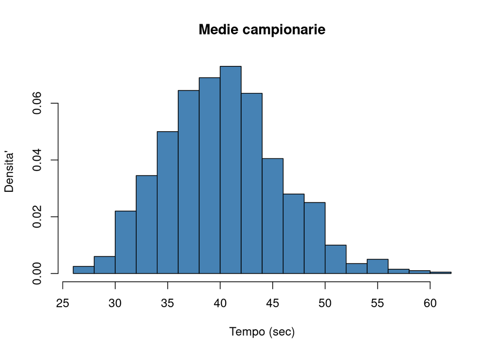

```r
hist(medie, col = "steelblue", main = "Medie campionarie", xlab = "Tempo (sec)", ylab = "Densita' ", freq = FALSE, breaks = 15)
```

Nella chiamata alla funzione `hist` oltre ad alcuni argomenti il cui significato è facilmente intuibile, ovvero `col`, `main`, `xlab` e `ylab`, abbiamo due argomenti che meritano un po’ di commento:

- l’argomento `freq = FALSE` è necessario per far sì che l’istogramma riporti le densità e non le frequenze,
- l’argomento `breaks = 15` serve per suddividere l’istogramma approssimativamente in 15 intervalli. **R** prende questo come un suggerimento e sceglie un numero di intervalli vicino a 15 che soddisfi alcune regole per rendere l’istogramma sufficientemente “equilibrato”.

L’istogramma delle 1000 medie campionarie ha una forma che ricorda quella di una distribuzione normale. Questo è un risultato che ci aspettiamo vista la **normalità asintotica** della media campionaria. La varianza della distribuzione esponenziale di parametro $\lambda$ è $1/\lambda^2$ (verificatelo) e, quindi, la varianza della media campionaria è pari $1/(n \lambda^2)$. Siccome nel nostro caso abbiamo che **$n=50$** e $\lambda=1/40.35$, allora la media campionaria ha una distribuzione campionaria approssimativamente normale con media $40.35$ e varianza $40.35 ^ 2 / 50.$

Proviamo ad aggiungere la densità di questa distribuzione normale all’istogramma precedente per vedere quanto la teoria sia coerente con i i risultati campionari. La densità di una distribuzione normale in **R** si ottiene con la funzione `dnorm` che richiede di specificare la media (`mean`) e la deviazione standard (`sd`):

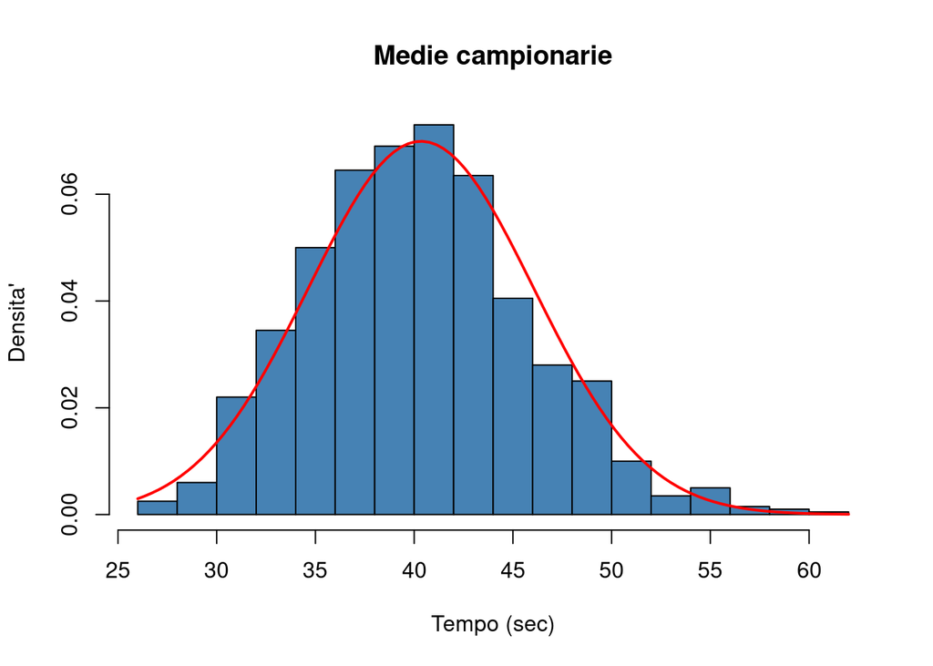

```r
hist(medie, col = "steelblue", main = "Medie campionarie", xlab = "Tempo (sec)", ylab = "Densita' ", freq = FALSE, breaks = 15)
curve(dnorm(x, mean = media.pop, sd = media.pop / sqrt(50)), add = TRUE, col = "red", lwd = 2) ## lwd = 2 indica uno spessore (`line width') doppio rispetto al valore di default
```

Infine, verifichiamo empiricamente anche la **consistenza** della media campionaria. Di seguito calcoliamo la media campionaria per campioni via via più grandi a partire da un campione di una sola osservazione fino ad un campione che comprende tutte le osservazioni. Un modo efficiente per eseguire questo esercizio consiste per prima cosa nel permutare le osservazioni della popolazione usando la funzione **sample**:

```r
## fissiamo il seme del generatore pseudo-casuale per
## garantire la reproducibilita' delle analisi
set.seed(5555)
permutazione <- sample(popolazione)
## permutazione ha la stessa dimensione di popolazione
length(permutazione)
```

```
## [1] 5000
```

```r
## le prime sei osservazioni permutate
head(permutazione)
```

```
## [1] 14.25791 37.96300 14.37224 63.98297 15.26814 28.76971
```

Ora considereremo la prima osservazione del vettore **permutazione** come il campione di dimensione uno, le prime due osservazioni di **permutazione** come il campione di dimensione due e così via. Dobbiamo calcolare le medie di questi campioni di dimensione crescente e possiamo farlo in modo efficiente utilizzando la funzione `cumsum(x)` che calcola il vettore delle “somme cumulate” di `x`, ovvero un vettore il cui elemento i-esimo è la somma dei primi i elementi del vettore `x`. Le somme cumulate del vettore **permutazione** sono quindi i numeratori delle medie campionarie dei campioni di dimensione crescente che devono poi essere divisi per le rispettive dimensioni campionarie:

```r
numeratori <- cumsum(permutazione)
## i denominatori sono la sequenza di numeri da 1 a 5000
denominatori <- 1:5000
head(denominatori)
```

```
## [1] 1 2 3 4 5 6
```

```r
medie <- numeratori / denominatori
## medie ha dimensione 5000
length(medie)
```

```
## [1] 5000
```

```r
## le prime sei medie...
head(medie)
```

```
## [1] 14.25791 26.11045 22.19772 32.64403 29.16885 29.10233
```

Infine, disegniamo la sequenza di medie campionarie ottenute con i campioni di dimensioni crescenti e le confrontiamo con la media di popolazione:

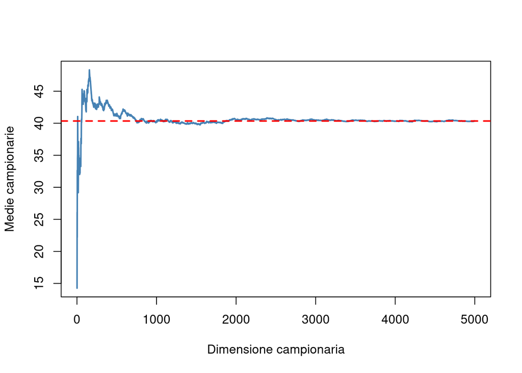

```r
## grafico a dispersione della sequenza di medie campionarie
plot(medie, col = "steelblue", type = "l", lwd = 2, ylab = "Medie campionarie", xlab = "Dimensione campionaria")
## type = "l" indica di disegnare una linea ('l')
## aggiungiamo una linea tratteggiata rossa orizzontale corrispondente alla media di popolazione:
abline(h = media.pop, lty = "dashed", col = "red", lwd = 2)
```

Il grafico mostra chiaramente come al crescere della dimensione campionaria, la media campionaria converga alla media di popolazione.

[^1]: Nel dubbio su come utilizzare una funzione **R** potete sempre consultare la guida in linea digitando, in questo caso, `help(dexp)`.